# Linkage Estimation with haplotypes

Yanlin Liao

10/14/2020

In this tutorial, we will go through the basic steps to perform linkage analysis in polyploids by using multi-allelic markers (haplotypes). The example dataset is a simulated dataset (by PedigreeSim) of a hypothetical tetraploid outcrossing plant species with one chromosome. It is a F1 population with 200 individuals between two non-inbred parents. Both parents are assumed to follow polysomic inheritance (random bivalent pairing).

## Table of Contents

1. Introduction
2. Load functions
3. Importing data and specify general terms
4. Generate equations
5. Estimate how offspring inherit gametes from parents under assumed inheritance
6. Perform linkage analysis
7. Results evaluation
8. References

## 1. Introduction

Linkage analysis is a genetic method to understand the segregation of genes which demonstrates the recombination landscape within a species (from a single cross). *TetraploidSNPMap* (Hackett et al. 2017), *PolyGembler* (Zhou et al. 2017), *polymapR* (Bourke et al. 2018), *MAPpoly* (Mollinari and Garcia 2019), and *netgwas* (Behrouzi et al. 2019) allow us to perform linkage analysis using bi-allelic SNP markers. As the allele within a bi-parental population are inherited as blocks, we would expect clustering markers into haploblocks would contain more information. Here, haploblock contains multiple sequence of genomic variants, typically SNPs, within a narrow contig, where no recombination happen within each block (Wang, Akey, Zhang, Chakraborty, & Jin, 2002). In linkage study of two bi-allelic markers, phasing can be repulsion, coupling, or mixed, where the capacity to map each allele is limited. The use of haploblock, assigning multiple bi-allelic markers into one (therefore, we can also name it as multi-allelic marker), allows us to map more alleles and lead to haplotype maps directly after linkage estimation. This study introduced a new approach that estimates recombination frequency and phasing with haplotypes. An example of one tetraploid F1 population was given for illustration. Here we used different letters to represent the unique haplotypes. In a tetraploid, if we notate the unique haplotypes A, B, C and D, when we look at one parent, we could distinguish ABCD, AABB, AABC, and AAAB in an individual.

## 2. Load functions

`mappire` is still under development.This package requires these deficiencies. Please first make sure that your computer already installed these packages:

```r
library(Deriv); library(combinat);library(dplyr)
library(foreach); library(doParallel)
library(randomcoloR); library(ggplot2)
library(combinat); library(simplr);library(reshape2)
```

To install *mappire*, firstly you need map to the correct folder (as directory) and then use this command to install this package (from tar file):

```r
setwd('workshop_20201202')
install.packages("mappire_0.1.1.tar")
library(mappire)
```

## 3. Importing data and specify general terms

To make it easy to understand, all the example dataset is already loaded in the package. If you want to view the data, you can use *data(xxx)*. To start our analysis, first we need to specify the ploidy level of your crop. At the same time, *mappire* could run parallel with many cores, based on your computer setting, define how many cores you want to use (normally less than your capcaity). The number of cores can be checked by *detectCores()*. Before start, please also make sure that you map your working directory to the right folder. This can be achieved by using *setwd()*. Set the working dictionary and assign it as Total_path, then give a proper file name where you want to put your experimental results.

```r
ploidy <- 4
cores <- 4
```

In this study, the dataset was generated by PedigreeSim (Voorrips & Maliepaard, 2012). We can upload by:

```r
folder_name <- 'workshop'
dsg_table <- readRDS(paste0('workshop_dataset/',folder_name,'.RDS'))
```

To convert it to the working format, we can:

```r
poly <- format_results(dosages = dsg_table,ncores = cores,ploidy = ploidy,Parent1 = 'P1',Parent2 = 'P2')
```

In our dataset (*poly*), there are different types of markers. Here we can use this to obtain the each marker’s marker type, sharing percentage, and give an overview of its distribution.

```r
MT <- MarkerType_Overview(poly = poly,
                          ploidy = ploidy,
                          plot = TRUE)
save(MT,file = 'MT.RData')
```

The notation here for different types of markers becomes different. 1_1_1_1: ABCD; 1_1_2: AABC; 1_3: AAAB; 2_2: AABB. In our dataset, the distribution of the dataset is:

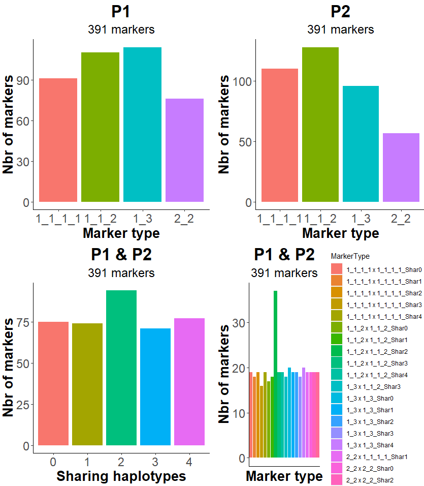

## 4. Generate equations

In haplotype mapping, we made a generalized equation for linkage estimation according to the ploidy levels. It is suggested to generate before performing analysis. Here we can call:

```r
tetraploid_equation <- bivalent_equation_generator(ploidy = ploidy)
```

This equation is generalized probability equation of all possible gametes. However, when it need to adapt to different marker types, it need to be converted. This can be achieved by (it might take some time for running):

```r
all_equations <- all_equations_generator(P1_inheritance = 'Polysomic',
                                         P2_inheritance = 'Polysomic',
                                         MT = MT,
                                         ploidy = ploidy)
save(all_equations,file = 'all_equations.RData')
```

Here, the *all_equation* includes all gametes possibility equations for P1 and P2 separately, adapted according to their marker types.

## 5. Estimate how offspring inherit gametes from parents under assumed inheritance

The count of offspring gametes from one parent can be estimated under assumed inheritance. Under one assumed inheritance combination, for given parental and offspring genotypes we can infer the origin of the offspring alleles. In this tutorial, both parents are assumed to follow polysomic inheritance. By separating parents, it also allows us to perform analysis for parents with different inheritance (this can be another tutorial in the future). To estimate the probability how offspring inherit gametes from parents, we can call:

```r
offspring_score_list <- Infer_offspring_inheritance(poly =poly,
                                                    ploidy = ploidy,
                                                    P1_inheritance = 'Polysomic',
                                                    P2_inheritance = 'Polysomic')
save(offspring_score_list,file = 'offspring_score_list.RData')
```

The output include a list of all markers. Within each marker,it include the missing_nbr(estimated number of missing individuals), and all possible pairing configuration, with the probability of each gametes.

## 6. Perform linkage analysis

To store our data and plots, we can create two folders:

```r
dir.create('Result_1');dir.create('Plot_1')
```

Then, we can perform the linkage analysis, in our example, we will look at the ABCD_EFGH marker x ABCD_EFGH marker. The linkage can be performed by calling:

```r
Linkage_res <- Haplotype_linkage(Mrk_P = 'ABCD_EFGH',
                                   Mrk_Q = 'ABCD_EFGH',
                                   offspring_score_list = offspring_score_list,
                                   poly = poly,
                                   cores = cores,
                                   MT = MT,
                                   all_equations = all_equations,
                                   pairing = NULL)
saveRDS(Linkage_res,file = paste0('Result_1/ABCD_EFGHxABCD_EFGH.RDS'))
```

The output linkage estimation result includes the markers for two markers, for each marker, their recombination frequency and LOD score, and estimated haplotype phasing. More detailed description of analysis can be found in Haplotype_linkage function annotation in exported_functions.R file.

## 7. Results evaluation

To evaluate whether our linkage function could give us a good estimates, we first need to upload the simulated files (.gen and .map), which is generated by PedigreeSim.

```r
genfile <- readDatfile(paste0('workshop_dataset/',folder_name,'.gen'),sep = ' ',stringsAsFactors=F,colClasses = c("character"))
mapfile <- readDatfile(paste0('workshop_dataset/',folder_name,'.map'),sep = ' ',stringsAsFactors=F)
```

To evaluate the results, we can call:

```r
evaluated_res <- results_evaluation(result = Linkage_res$output,
                   genfile = genfile,
                   mapfile = mapfile,
                   plot =TRUE,
                   filename = 'ABCD_EFGHxABCD_EFGH')
```

Four figures will be plotted for comparing the simulated dataset and estimated phasing:1) r vs. LOD; 2)true r vs. estimated r (phasing correctness as groups); 3) r vs. LOD (wrongly phased); 4) r vs. LOD (correctly phased)

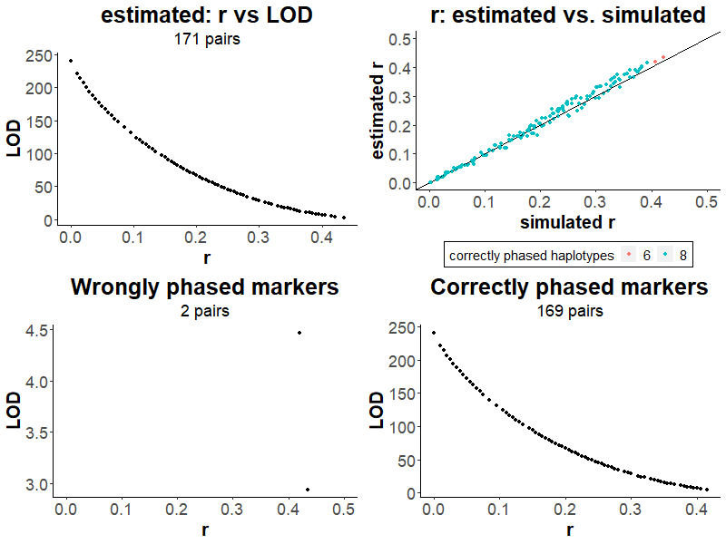

## 8. References

1. Behrouzi, Pariya, Danny Arends, and Ernst C Wit. 2017. “Netgwas: An R Package for Network-Based Genome-Wide Association Studies.” arXiv preprint arXiv:1710. https://cran. (July 3, 2019).
2. Bourke, Peter M et al. 2018. “PolymapR - Linkage Analysis and Genetic Map Construction from F 1 Populations of Outcrossing Polyploids” ed. Oliver Stegle. Bioinformatics 34(20): 3496–3502. https://academic.oup.com/bioinformatics/article/34/20/3496/4990829 (April 11, 2019).
3. Hackett, C.A. et al. 2017. “TetraploidSNPMap: Software for Linkage Analysis and QTL Mapping in Autotetraploid Populations Using SNP Dosage Data.” Journal of Heredity 108(4): 438–42.
4. Mollinari, Marcelo, and Antonio Augusto Franco Garcia. 2019. “Linkage Analysis and Haplotype Phasing in Experimental Autopolyploid Populations with High Ploidy Level Using Hidden Markov Models.” G3 (Bethesda, Md.) 9(10): 3297–3314. https://www.biorxiv.org/content/10.1101/415232v2 (July 3, 2019).
5. Voorrips, Roeland E, and Chris A Maliepaard. 2012. “The Simulation of Meiosis in Diploid and Tetraploid Organisms Using Various Genetic Models.” BMC Bioinformatics 13(248).
6. Wang, Ning et al. 2002. “Distribution of Recombination Crossovers and the Origin of Haplotype Blocks: The Interplay of Population History, Recombination, and Mutation.” The American Journal of Human Genetics 71(5): 1227–34. https://www.sciencedirect.com/science/article/pii/S0002929707604182 (September 24, 2019).
7. Zhou, Chenxi et al. 2017. “Assembly Of Whole-Chromosome Pseudomolecules For Polyploid Plant Genomes Using Outcrossed Mapping Populations.” bioRxiv. http://biorxiv.org/content/early/2017/03/22/119271 (October 23, 2019).